# CopulaR

Toke Zinn 1/9/2020

# Introduction

`CopulaR` is a lightweight vectorised, but non-optimised, copula framework in R. Copulas are multivariate distribution functions which have uniform marginals. Our interest in copulas primarily comes from Sklar’s theorem stating that any multivariate distribution

[figure not shown]

can be decomposed into its marginals

[figure not shown]

and a copula

[figure not shown]

.

## Regular Use

`CopulaR` automatically approximates the density given a copula function. Conversely, given a copula density it approximates the copula. We do this through initialisation, namely the `S4` class `Copula` takes either the density or the copula as an input, i.e.

```r
# Initialise with density
Independence = Copula(density = function(u,v){1})

# Initialise with copula
Independence_Alternative = Copula(copula = function(u,v){u*v})
```

The initialisation is rather slow. However, once initialised the framework is rather fast at sampling and evaluating. In order to evaluate the density, copula, or sample we use the functions `d`, `p`, and `r` respectively.

```r
#Evaluate density
d(Independence)(0.5,0.5)
```

```
## [1] 1
```

```r
#Evaluate copula
p(Independence)(0.5,0.5)
```

```
## [1] 0.25
```

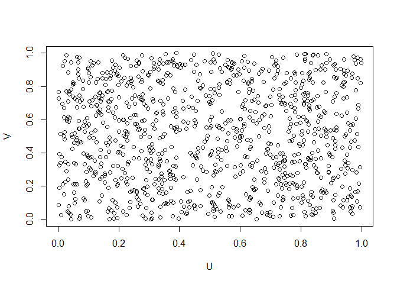

```r
#Sample from the copula (here 1000 points)
plot(r(Independence)(1000), xlab = "U", ylab = "V")
```

Sampling is *rather* fast, although it can be optimised.

```r
microbenchmark::microbenchmark(r(Independence)(10000), times = 10)
```

```
## Unit: milliseconds
##                    expr      min       lq     mean   median       uq      max
##  r(Independence)(10000) 442.3189 456.5712 472.2826 468.5299 494.6909 513.8638
##  neval
##     10
```

Furthermore, a standard plotting method is available. We can specify whether we want to plot the copula

[figure not shown]

, the density

[figure not shown]

, the partial derivatives

[figure not shown]

,

[figure not shown]

using the `surface` argument. Standard surface is

[figure not shown]

.

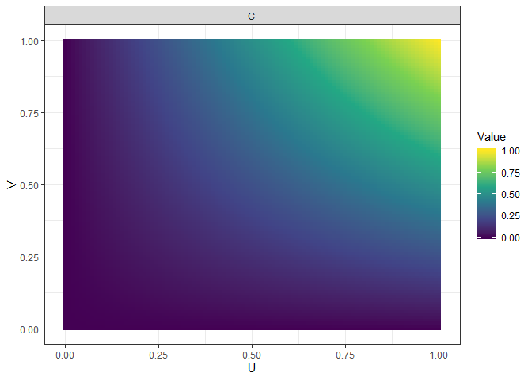

```r
#plot the copula
plot(Independence)
```

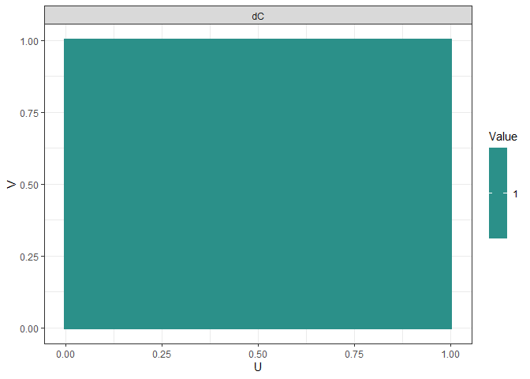

```r
#plot the density
plot(Independence, surface = dC)
```

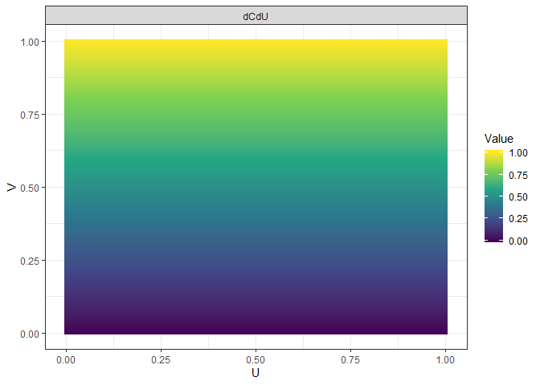

```r
#plot dC/dU
plot(Independence, surface = dCdU)
```

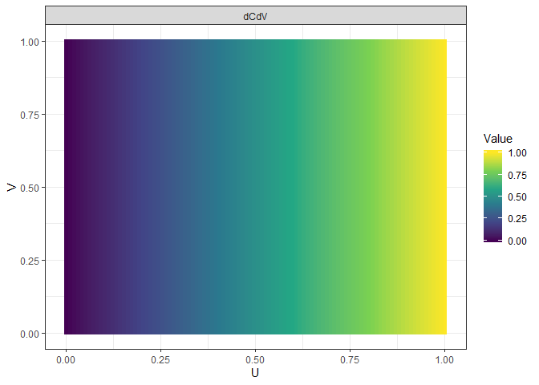

```r
#plot dC/dV
plot(Independence, surface = dCdV)
```

# Methods

We present several methods implemented for the copula object. Throughout this section let

[figure not shown]

denote the set of bi-variate copulas. Recall that a copula

[figure not shown]

is Lipschitz, and thus by Rademacher’s Theorem it is differentiable *almost everywhere*, i.e. the set of points where

[figure not shown]

is not differentiable has Lebesgue measure

[figure not shown]

.

## The asterisk product

Let

[figure not shown]

and

[figure not shown]

with

[figure not shown]

. We define

[figure not shown]

Then

[figure not shown]

is a copula, and the probabilistic interpretation is that

[figure not shown]

is the copula of

[figure not shown]

given that

[figure not shown]

are conditionally independent given

[figure not shown]

. First we initialise two copulas; a Clayton copula with

[figure not shown]

and a Gaussian copula with

[figure not shown]

.

```r
A = Copula(copula = function(u,v){
  theta  = 3

  A = u^(-theta) + v^(-theta) - 1

  (A*(A>0))^(-1/theta)

})


B = Copula(copula = function(u,v){
  apply(X = cbind(qnorm(u),qnorm(v)),MARGIN = 1,FUN =  pmvnorm, lower = -Inf, sigma = cbind(c(1,0.9),c(0.9,1)))
})
```

We then apply the

[figure not shown]

operation using `%ast%`

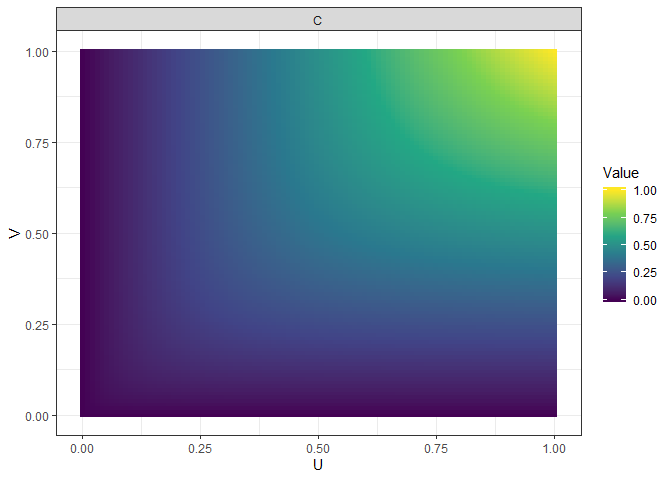

```r
C = A %ast% B

plot(C)
```

Sampling from the new copula is readily available

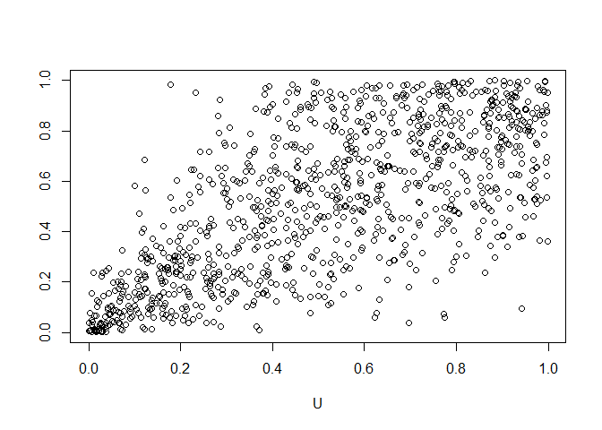

```r
plot(r(C)(1000))
```

## Convex Combinations

The space

[figure not shown]

is closed under convex combinations. That is, let

[figure not shown]

, then

[figure not shown]

where addition for copulas is defined pointwise in

[figure not shown]

.

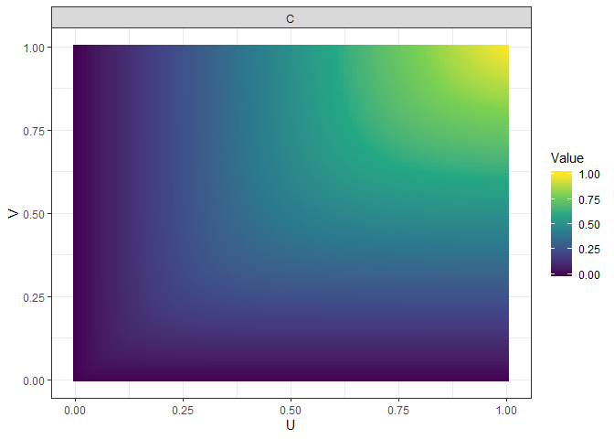

```r
D = Convex(A,B,0.5)

plot(D, surface = C)
```

# Approximation Methods and Internals

We briefly discuss how the internals of the package works. The following is rather loose treatment of the subject.

## Approximation of Copula, Density, and Partial Derivatives

Suppose we initialse the copula `C` using the `copula` argument. The function is then evaluated on a

[figure not shown]

mesh with

[figure not shown]

where

[figure not shown]

belongs to some partition of

[figure not shown]

and

[figure not shown]

to some, possibly different, partition of

[figure not shown]

.

Since copulas are differentiable almost everywhere, we apply (bi)linear interpolation between the points on the grid, with the expectation that the approximation is *reasonable*. This may be subject to change to better approximations methods. Similarly, the density and partial derivatives are linearly interpolated.

In term of calculating partial derivates we have implemented the function `Partial_Derivative` in accordance with the `dplyr` and `tidyverse` framework; the grid

[figure not shown]

is expanded into “long” format, i.e. a dataframe with each row being a tuple

[figure not shown]

for each

[figure not shown]

and

[figure not shown]

. In order to take a partial derivative we, say

[figure not shown]

we group by

[figure not shown]

and apply the standard numerical derivatives; central differencing in the interior and forwards or backwards differencing on the boundary. The code is provided below.

```r
Partial_Derivative = function(.Data, Z, X, ...,  Name){
  if(missing(Name)){Name = paste0("d",as_string(ensym(Z)),"d",as_string(ensym(X))) }else{ Name = as_string(ensym(Name))}

  # Identify the Boundary

  boundary = .Data %>% pull({{X}}) %>% {c(min(.),max(.))}

  # Differencing
  .Data %>%
    group_by_at(vars(...,-{{Z}},-{{X}})) %>%
    arrange({{X}}) %>%
    mutate(!!Name := case_when(
      {{X}} == boundary[1] ~ (lead({{Z}}) - {{Z}})/(lead({{X}})-{{X}}),
      {{X}} == boundary[2] ~ ({{Z}} - lag({{Z}}))/({{X}} - lag({{X}})),
      TRUE ~ (lead({{Z}})- lag({{Z}}))/(lead({{X}})-lag({{X}}))
    )) %>% ungroup()

}
```